# Bellabeat project

#### Take a look at the Sleep_day date.

```r
glimpse(sleep_day)
```

```
## Rows: 413
## Columns: 5
## $ Id                 <dbl> 1503960366, 1503960366, 1503960366, 1503960366, 150…
## $ SleepDay           <chr> "4/12/2016 12:00:00 AM", "4/13/2016 12:00:00 AM", "…
## $ TotalSleepRecords  <int> 1, 2, 1, 2, 1, 1, 1, 1, 1, 1, 1, 1, 1, 1, 1, 1, 1, …
## $ TotalMinutesAsleep <int> 327, 384, 412, 340, 700, 304, 360, 325, 361, 430, 2…
## $ TotalTimeInBed     <int> 346, 407, 442, 367, 712, 320, 377, 364, 384, 449, 3…
```

- Remove duplicates

```r
sleep_day <- unique(sleep_day)
```

- Formatting data We transform SleepDate from Character to Date. Then, change TotalSleepRecords from integer to factor

```r
sleep_day$SleepDay <- as.Date(mdy_hms(sleep_day$SleepDay))
sleep_day$TotalSleepRecords <- as.factor(sleep_day$TotalSleepRecords)
is.Date(sleep_day$SleepDay)
```

```
## [1] TRUE
```

- Take a look at the statistical summary of sleep_day.

```r
sleep_day %>%
  select(-c(Id, SleepDay)) %>%
  summary()
```

```
##  TotalSleepRecords TotalMinutesAsleep TotalTimeInBed
##  1:364             Min.   : 58.0      Min.   : 61.0
##  2: 43             1st Qu.:361.0      1st Qu.:403.8
##  3:  3             Median :432.5      Median :463.0
##                    Mean   :419.2      Mean   :458.5
##                    3rd Qu.:490.0      3rd Qu.:526.0
##                    Max.   :796.0      Max.   :961.0
```

FitBit’s Customers usualy sleep for 419 mins (equivalent to approximately 7 hours a day)

Similar to Daily_actitity, we inspect the time for sleeping of the users using the Fitbit. However, because of the lack of observations, we will use the information of customer whose sleep recorded in at least 2 weeks.

```r
Sub_sleep_day <- sleep_day %>%
  group_by(Id) %>%
  select(c(Id, SleepDay,TotalMinutesAsleep)) %>%
  mutate(Avg_Asleep_minutes = mean(TotalMinutesAsleep))
```

```r
Number_date_recorded1 <- as.data.frame(table(Sub_sleep_day$Id)) %>%
  filter(Freq >= 14)
length(unique(Number_date_recorded1$Var1))
```

```
## [1] 15
```

Let see how many users slept for at least 7 hours on average

```r
At_least_7hours <- Sub_sleep_day %>%
  filter(Id %in% Number_date_recorded1$Var1) %>%
  filter(Avg_Asleep_minutes >= 420)
length(unique(At_least_7hours$Id))
```

```
## [1] 10
```

#### Merge daily_activity and sleep_day to inspect the relationship between variables from to tables

```r
combined_data <- merge(daily_activity_normalized, sleep_day, by = "Id")
head(combined_data)
```

```
##           Id ActivityDate TotalDistance VeryActiveDistance
## 1 1503960366   2016-05-07          7.71               2.46
## 2 1503960366   2016-05-07          7.71               2.46
## 3 1503960366   2016-05-07          7.71               2.46
## 4 1503960366   2016-05-07          7.71               2.46
## 5 1503960366   2016-05-07          7.71               2.46
## 6 1503960366   2016-05-07          7.71               2.46
##   ModeratelyActiveDistance LightActiveDistance SedentaryActiveDistance
## 1                     2.12                3.13                       0
## 2                     2.12                3.13                       0
## 3                     2.12                3.13                       0
## 4                     2.12                3.13                       0
## 5                     2.12                3.13                       0
## 6                     2.12                3.13                       0
##   TotalActiveMinutes VeryActiveMinutes FairlyActiveMinutes LightlyActiveMinutes
```

[output cut: 20 more lines]

#### Plotting 1 includes the sum and other variables

```r
combined_data1 <- combined_data %>%
  select(-c(Id,ActivityDate, SleepDay, VeryActiveDistance, ModeratelyActiveDistance, LightActiveDistance, VeryActiveMinutes, FairlyActiveMinutes,TotalSleepRecords))
head(combined_data1)
```

```
##   TotalDistance SedentaryActiveDistance TotalActiveMinutes LightlyActiveMinutes
## 1          7.71                       0                 83                  175
## 2          7.71                       0                 83                  175
## 3          7.71                       0                 83                  175
## 4          7.71                       0                 83                  175
## 5          7.71                       0                 83                  175
## 6          7.71                       0                 83                  175
##   SedentaryMinutes Calories TotalSteps TotalMinutesAsleep TotalTimeInBed
## 1              833     1821  0.3329354                327            346
## 2              833     1821  0.3329354                384            407
## 3              833     1821  0.3329354                412            442
## 4              833     1821  0.3329354                340            367
## 5              833     1821  0.3329354                700            712
## 6              833     1821  0.3329354                304            320
```

We calculate the correlation coefficients

```r
correlation1<- cor(combined_data1)
```

Visualize with a heatmap

```r
heatmap1 <- melt(correlation1)
head(heatmap1)
```

```
##                      Var1          Var2       value
## 1           TotalDistance TotalDistance  1.00000000
## 2 SedentaryActiveDistance TotalDistance  0.07562118
## 3      TotalActiveMinutes TotalDistance  0.70824462
## 4    LightlyActiveMinutes TotalDistance  0.51256520
## 5        SedentaryMinutes TotalDistance -0.31407273
## 6                Calories TotalDistance  0.55069644
```

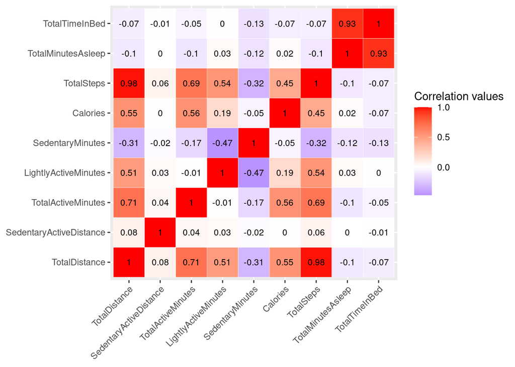

```r
ggplot(data = heatmap1, aes(x= Var1, y=Var2, fill = value)) +
  geom_tile(color="white") +
  scale_fill_gradient2(low = "blue",high= "red", mid = "white", midpoint = 0) +
  theme(axis.text.x = element_text(angle = 45,vjust = 1, hjust = 1),
        axis.title.x = element_blank(), axis.title.y = element_blank())+
  labs(fill = 'Correlation values') + geom_text(aes(label= round(value,2)),
                                                color = 'black', size= 3)
```

From the heatmap, some relations should be considered significant (higher or approximately to 0.8)

**TotalSteps** and **TotalDistance**

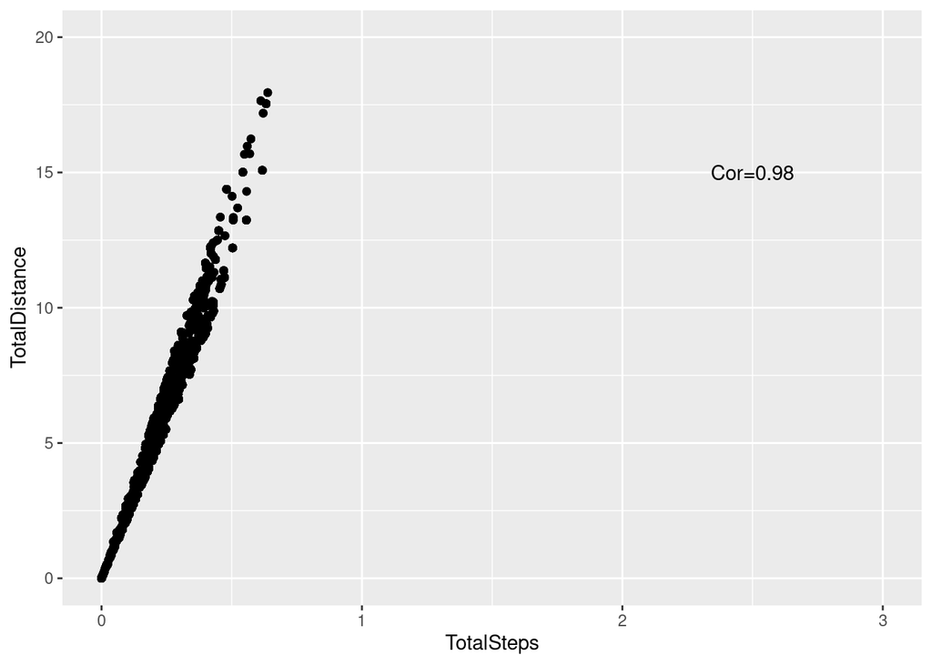

```r
ggplot(data=combined_data1) + geom_point(mapping = aes(x=TotalSteps,y= TotalDistance))+   annotate("text", 2.5,15,label=paste0("Cor=",round(cor(combined_data1$TotalSteps,combined_data1$TotalDistance),2))) + ylim(0,20) + xlim(0,3)
```

**TotalTimeInBed** and **TotalMinutesAsleep**

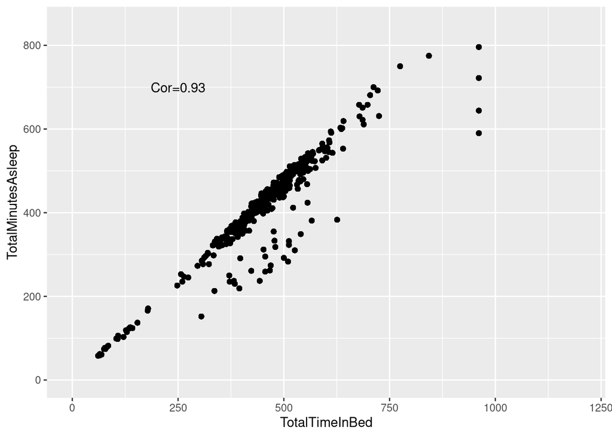

```r
ggplot(data=combined_data1) + geom_point(mapping = aes(x=TotalTimeInBed,y= TotalMinutesAsleep)) +
  annotate("text", 250,700,label=paste0("Cor=",round(cor(combined_data1$TotalTimeInBed,combined_data1$TotalMinutesAsleep),2))) + ylim(0,850) + xlim(0,1200)
```

#### Plotting 2 includes the elements of the sum and other variables

```r
combined_data2 <- combined_data %>%
  select(-c(Id,ActivityDate, SleepDay,TotalSleepRecords, TotalDistance,TotalActiveMinutes))
head(combined_data2)
```

```
##   VeryActiveDistance ModeratelyActiveDistance LightActiveDistance
## 1               2.46                     2.12                3.13
## 2               2.46                     2.12                3.13
## 3               2.46                     2.12                3.13
## 4               2.46                     2.12                3.13
## 5               2.46                     2.12                3.13
## 6               2.46                     2.12                3.13
##   SedentaryActiveDistance VeryActiveMinutes FairlyActiveMinutes
## 1                       0                37                  46
## 2                       0                37                  46
## 3                       0                37                  46
## 4                       0                37                  46
## 5                       0                37                  46
## 6                       0                37                  46
##   LightlyActiveMinutes SedentaryMinutes Calories TotalSteps TotalMinutesAsleep
## 1                  175              833     1821  0.3329354                327
## 2                  175              833     1821  0.3329354                384
## 3                  175              833     1821  0.3329354                412
## 4                  175              833     1821  0.3329354                340
## 5                  175              833     1821  0.3329354                700
## 6                  175              833     1821  0.3329354                304
##   TotalTimeInBed
## 1            346
## 2            407
## 3            442
## 4            367
## 5            712
## 6            320
```

We calculate the correlation coefficients for this table

```r
correlation2 <- cor(combined_data2)
```

Visualize with heatmap

```r
heatmap2 <- melt(correlation2)
head(heatmap2)
```

```
##                       Var1               Var2      value
## 1       VeryActiveDistance VeryActiveDistance 1.00000000
## 2 ModeratelyActiveDistance VeryActiveDistance 0.24037875
## 3      LightActiveDistance VeryActiveDistance 0.07295066
## 4  SedentaryActiveDistance VeryActiveDistance 0.07139521
## 5        VeryActiveMinutes VeryActiveDistance 0.85796442
## 6      FairlyActiveMinutes VeryActiveDistance 0.29406749
```

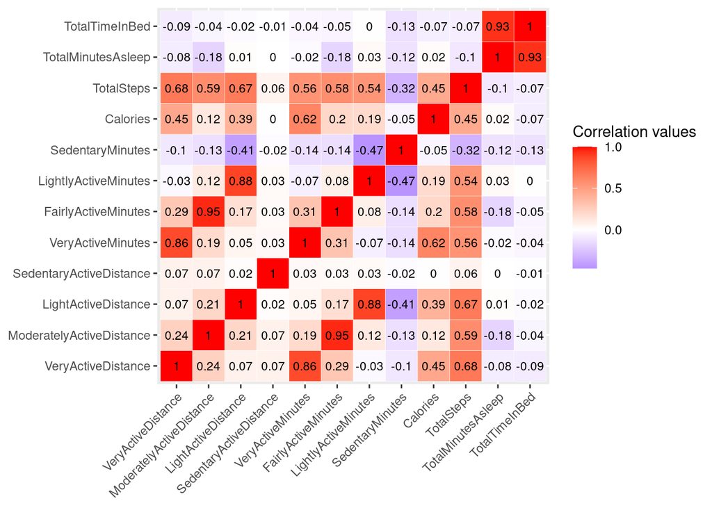

```r
ggplot(data = heatmap2, aes(x= Var1, y=Var2, fill = value)) + geom_tile(color="white")+
  scale_fill_gradient2(low = "blue", high = "red", mid = "white", midpoint = 0) + theme(axis.text.x = element_text(angle = 45,vjust = 1, hjust = 1),axis.title.x = element_blank(), axis.title.y = element_blank()) + labs(fill = 'Correlation values') + geom_text(aes(label= round(value,2)),color = 'black', size= 3)
```

Some relations should be considered significant (higher or approximately to 0.8)